# First project

# 1 Первое проектное задание:“На сколько стара мидия”

## 1.1 Создание набора данных для анализа

Перед тем как приступить к рассмотрению результатов исследовательской работы необходимо,чтобы в рабочей среде были установлены все необходимые пакеты. Для данной задачи применим функцию “require”, которая способна не только подключать пакет, но и скачивать его по необходимости.

```r
require(tidyverse)
require(dplyr)
require(psych)
require(RColorBrewer)
require(grid)
require(ggplot2)
require(tidyr)
require(purrr)
require(ggpubr)
require(PerformanceAnalytics)
require(plyr)
require(rstudioapi)
```

После того как все пакеты поодключены, необходимо создать функцию,которая способна собрать все исследовательские данные воедино, для этого используем объединим вместе 3 функции - “list.files”, “lapply()”,“read.csv”. “list.files” - осуществляет поиск всех файлов с расширением .csv, “lapply()” и “read.csv” в свою очередь отвечают за сборку нового набора данных. После применения функции выведем краткую сводку по созданному набору данных.

```
## 'data.frame':    4177 obs. of  9 variables:
##  $ Rings                                 : chr  "18" "14" "8" "12" ...
##  $ Sex..1...male..2...female..3...uvenil.: chr  "2" "3" "1" "1" ...
##  $ Length                                : chr  "0.575" "0.385" "0.475" "0.665" ...
##  $ Diameter                              : num  0.45 0.305 0.37 0.525 0.12 0.16 0.565 0.43 0.175 0.3 ...
##  $ Height                                : num  0.17 0.095 0.125 0.18 0.075 0.05 0.2 0.15 0.055 0.115 ...
##  $ Whole_weight                          : num  1.048 0.252 0.649 1.429 0.117 ...
##  $ Shucked_weight                        : num  0.3775 0.0915 0.347 0.6715 0.0455 ...
##  $ Viscera_weight                        : num  0.171 0.055 0.136 0.29 0.029 ...
##  $ Shell_weight                          : num  0.385 0.09 0.142 0.4 0.0345 0.015 0.494 0.221 0.018 0.0935 ...
```

## 1.2 EDA собранных данных. Визуализация и чистка

После визуальной оценки колонок становится видно, что некоторые переменные являются строками, это может сведетельствовать о наличии каких - то неверных значений. Для того чтобы осуществить чистку данных, необходимо получить значения и позиции ошибок в анализируемом датафрейме. Для поиска неверных значений была написана пользовательская функция, которая превращает все нечисловые данные в пропущенные значения (Na). Затем выдает все позиции пропусков в данных, которые потом визуализируются в изначально собранной таблице:

```
##
## [1] "col name is:" "Rings"
##
## [1] "3372" "->"   "nine"
##
## [1] "col name is:"
## [2] "Sex..1...male..2...female..3...uvenil."
##
## [1] "343" "->"  NA
## [1] "618"   "->"    "three"
## [1] "1374" "->"   "one"
## [1] "1399" "->"   "male"
##
## [1] "col name is:" "Length"
##
## [1] "136" "->"  NA
## [1] "1224" "->"   NA
## [1] "1738" "->"   NA
## [1] "1908" "->"   NA
## [1] "2886" "->"   NA
## [1] "3059" "->"   NA
## [1] "3103"                             "->"
## [3] "No data! I forgot to mesure it!("
##
## [1] "col name is:" "Diameter"
##
## [1] "240" "->"  NA
## [1] "429" "->"  NA
## [1] "633" "->"  NA
## [1] "1490" "->"   NA
## [1] "3025" "->"   NA
##
## [1] "col name is:" "Height"
##
## [1] "1878" "->"   NA
## [1] "3670" "->"   NA
##
## [1] "col name is:" "Whole_weight"
##
## [1] "1769" "->"   NA
##
## [1] "col name is:"   "Shucked_weight"
##
## [1] "1290" "->"   NA
## [1] "2678" "->"   NA
## [1] "3016" "->"   NA
##
## [1] "col name is:"   "Viscera_weight"
##
##
## [1] "col name is:" "Shell_weight"
##
## [1] "639" "->"  NA
## [1] "1835" "->"   NA
```

Как становится видно, в данных имеются как неточности, так и пропуски. В данном случае, поскольку ошибочных данных не так много и они разнообразны, то проще всего будет произвести их исправлене вручную. Пропущенных значений тоже не слишком много, поэтому дабы минимизировать влияние на выборки было принято решение ничего с ниме не делать, лишь исключать из конкретных анализов при помощи команды “na.rm = FALSE”. В конце также показана краткая сводка того, что произошло со всеми переменными. Следует отметить, что было изменено название колонки, отвечающей за пол, поскольку оно было громоздким.Также данная колонка была переведена в фактор. По смыслу - это не численная переменная.

```
## 'data.frame':    4176 obs. of  9 variables:
##  $ Rings         : num  18 14 8 12 4 4 12 8 6 8 ...
##  $ Sex           : Factor w/ 3 levels "Male","Female",..: 2 3 1 1 3 3 1 2 3 2 ...
##  $ Length        : num  0.575 0.385 0.475 0.665 0.28 0.22 0.72 0.55 0.235 0.4 ...
##  $ Diameter      : num  0.45 0.305 0.37 0.525 0.12 0.16 0.565 0.43 0.175 0.3 ...
##  $ Height        : num  0.17 0.095 0.125 0.18 0.075 0.05 0.2 0.15 0.055 0.115 ...
##  $ Whole_weight  : num  1.048 0.252 0.649 1.429 0.117 ...
##  $ Shucked_weight: num  0.3775 0.0915 0.347 0.6715 0.0455 ...
##  $ Viscera_weight: num  0.171 0.055 0.136 0.29 0.029 ...
##  $ Shell_weight  : num  0.385 0.09 0.142 0.4 0.0345 0.015 0.494 0.221 0.018 0.0935 ...
```

Теперь, после того, как данные были преведены в порядок, можно приступать к их описанию, на основании которого будет составленно первичное представление того, с чем мы имеем дело. Для этого были использованы библиотеки “ggplot2”,“psych” и “RColorBrewer”. “ggplot2” - как основной инструмент, “psych” для получения коряляционной матрицы и базовых статистик,библиотека “RColorBrewer” использовалась как палитра.

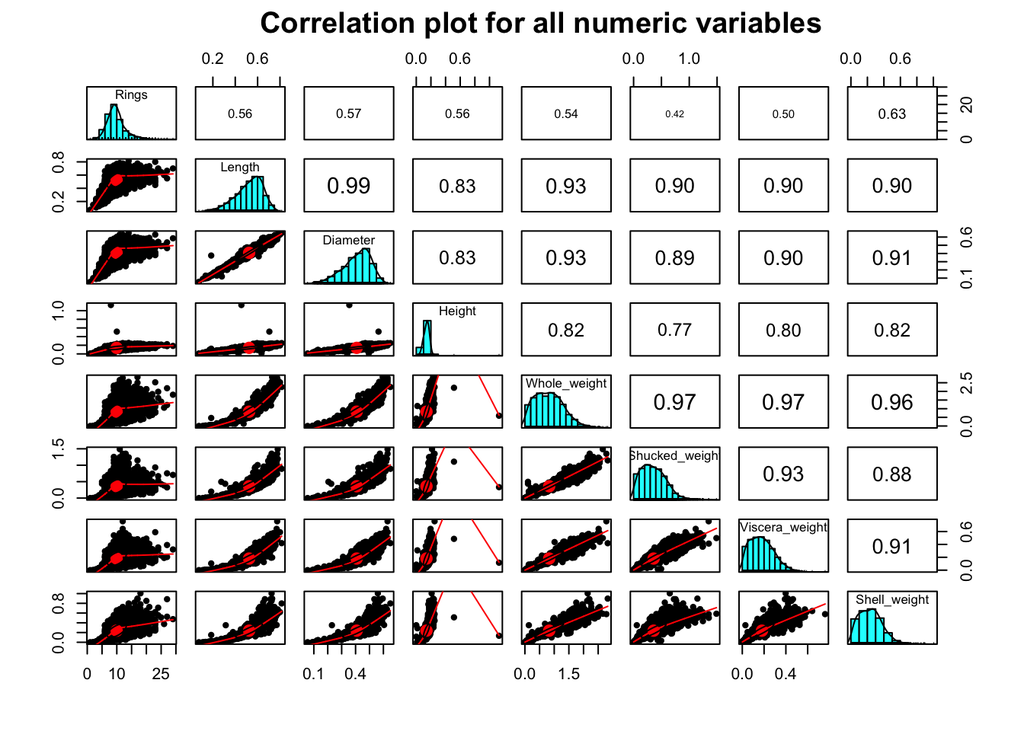

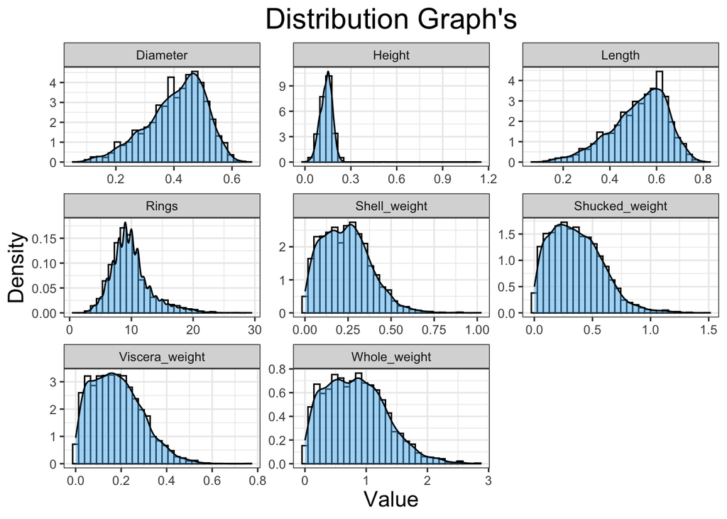

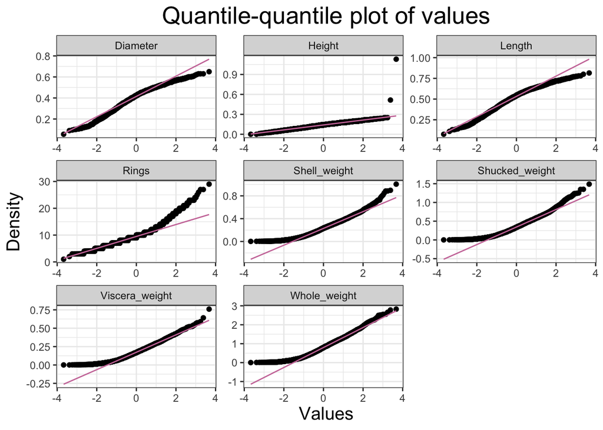

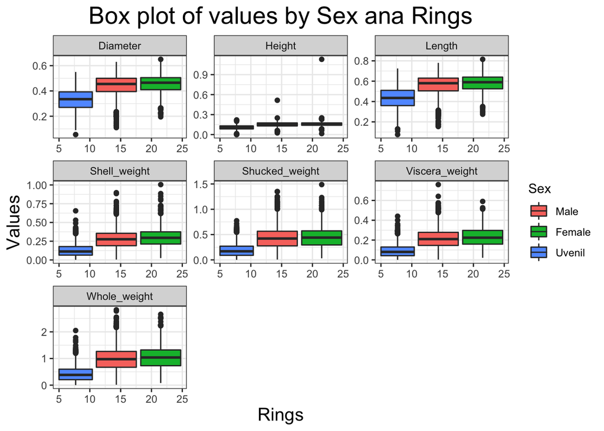

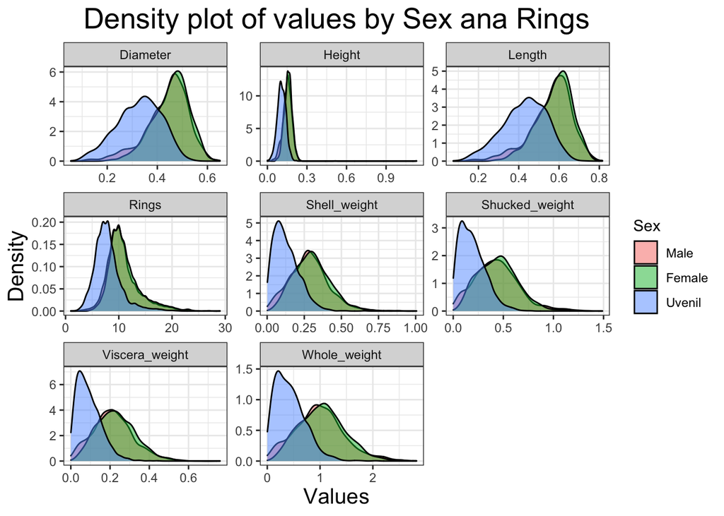

Для составления окончаначательного представления о полученных данных выведем краткую статистическую сводку при помощи библиотеки “psych” - функция “describe(test_data)[-2,]”. По мимо этого также пожно осуществить тест Шапиро-Уилка для формального взгляда на характер распределения.

```
##                vars    n mean   sd  min   max range   se
## Rings             1 4176 9.93 3.22 1.00 29.00 28.00 0.05
## Length            3 4169 0.52 0.12 0.08  0.82  0.74 0.00
## Diameter          4 4171 0.41 0.10 0.06  0.65  0.60 0.00
## Height            5 4174 0.14 0.04 0.00  1.13  1.13 0.00
## Whole_weight      6 4175 0.83 0.49 0.00  2.83  2.82 0.01
## Shucked_weight    7 4173 0.36 0.22 0.00  1.49  1.49 0.00
## Viscera_weight    8 4176 0.18 0.11 0.00  0.76  0.76 0.00
## Shell_weight      9 4174 0.24 0.14 0.00  1.00  1.00 0.00
```

```
##                statistic p.value
## Rings          0.9311702 3.314172e-40
## Length         0.9695445 7.069201e-29
## Diameter       0.9705917 1.925336e-28
## Height         0.8895086 1.172543e-47
## Whole_weight   0.9722467 9.886875e-28
## Shucked_weight 0.9621068 9.970822e-32
## Viscera_weight 0.9681113 1.744508e-29
## Shell_weight   0.9703511 1.488218e-28
```

Становится видно, что распределение переменных не является нормальным. Согласно графикам переменные “Lenght” и “Diameter” отклонена вправо, все остальные переменные влево. Исключение составляет переменная “Height”, которая является “сжатой”, что говорит о наличии выбросов, которые явно заметны на схемах плотностей, “box plot”, “qqplot”. Таким образом, необходимо удалить выбросы в переменной “Height”. При этом выбросы в остальных переменных, за некоторым исключением, трогать не следует, так как они многочисленны и расположенн близко к друг-другу. Это может исказить результат дальнейших тестов.

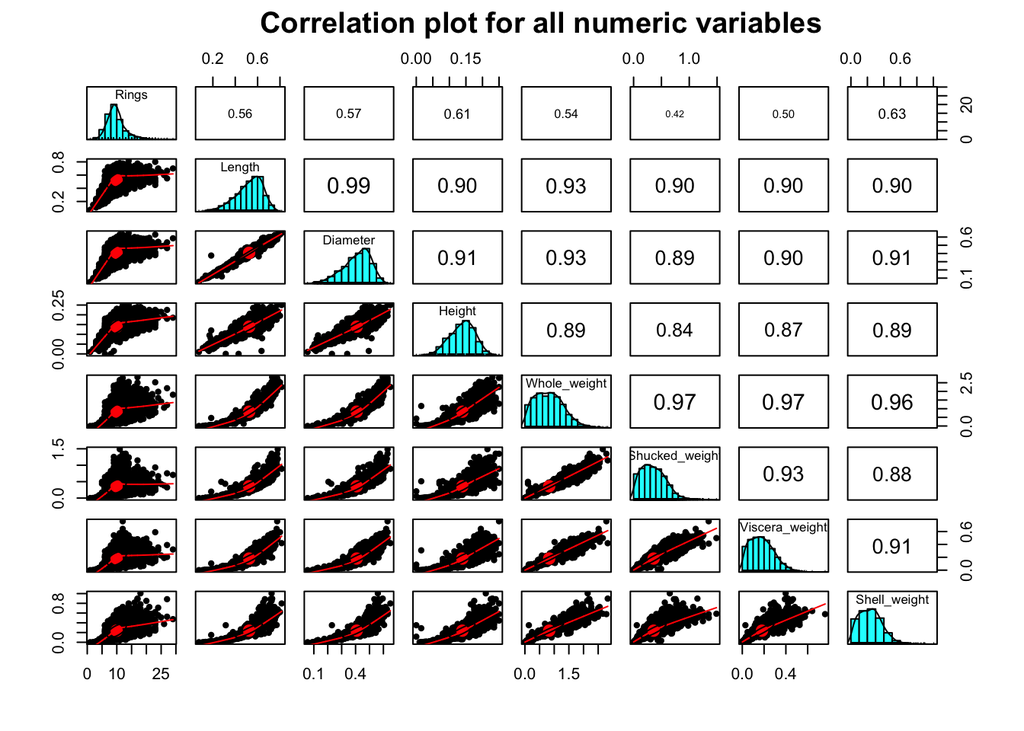

После удаления выбросов можно заметить, что переменная “Height” также как и переменные “Lenght” и “Diameter”отклонена вправо, однако, это отклонения выраженно в меньшей степени. Следующее, что можно увидеть - это то, что все переменные так или иначе кореллируют друг с другом. Причем линейно взаимодействуют между собой переменные “Length” и “Height”, “Length” и “Diameter”, “Diameter” и “Height”, “Whole_weight” и “Shucked_weight”, а также “Whole_weight” и “Viscera_weight”. Характер взаимодействия остальных переменных является не линейным.

Подводя краткие итоги, в процессе EDA были выявлены выбросы в переменной “Height” и составленно краткое представление о взаимодействии переменных в исследуемых данных.

## 1.3 Работа с переменной “Length”. Рассчет среднего и стандартного отклонения для молюсков разного пола

Визуализируем график распределения переменной “Length” и отметим на нем среднее значение пунктиром. После этого выведем требуемые значения среднего и стандартного отклонения.

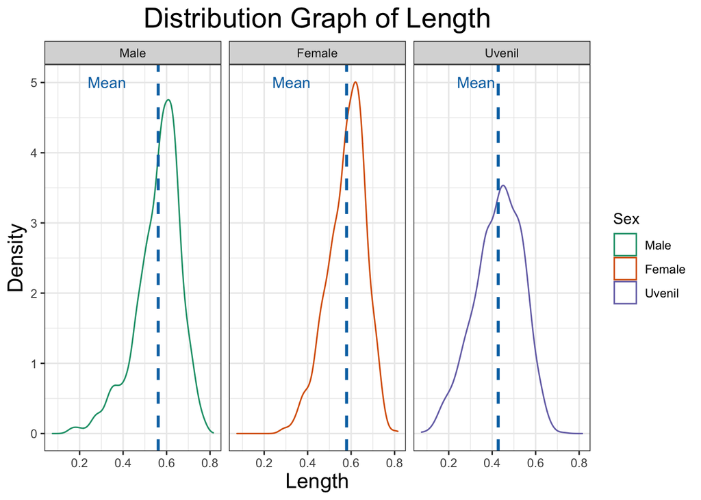

```
##      Sex  grp.mean     grp.sd
## 1   Male 0.5615629 0.10260811
## 2 Female 0.5791750 0.08625859
## 3 Uvenil 0.4277761 0.10893614
```

Согласно полученным данным становится видно, что плотность распределения всех 3 групп отклонена вправо, а также то, что среднее в группе “uvenil” отличается от средних в остальных группах.Глядя на показатели среднего отклонения можно саметить, что разброс значений по длинне у женских особей несколько меньще, нежели у мужских.

## 1.4 Работа с переменной Height. Процент мидий по высоте не превышающий 0.165

Рассчитаем интересуемый параметр, как отношение наблюдений, непревышающих 0.165 к общему объему выборки. Будем считать, что “не превышает” означает, что наблюдения имеющие значение высоты равное 0.165 также включаются в искомый процент.После того, как значение было высчитано визуализируем его на графике плотности распределения изучаемой выборки.

```
## Percentage of observations not exceeding 0.165 percent =  76 %
```

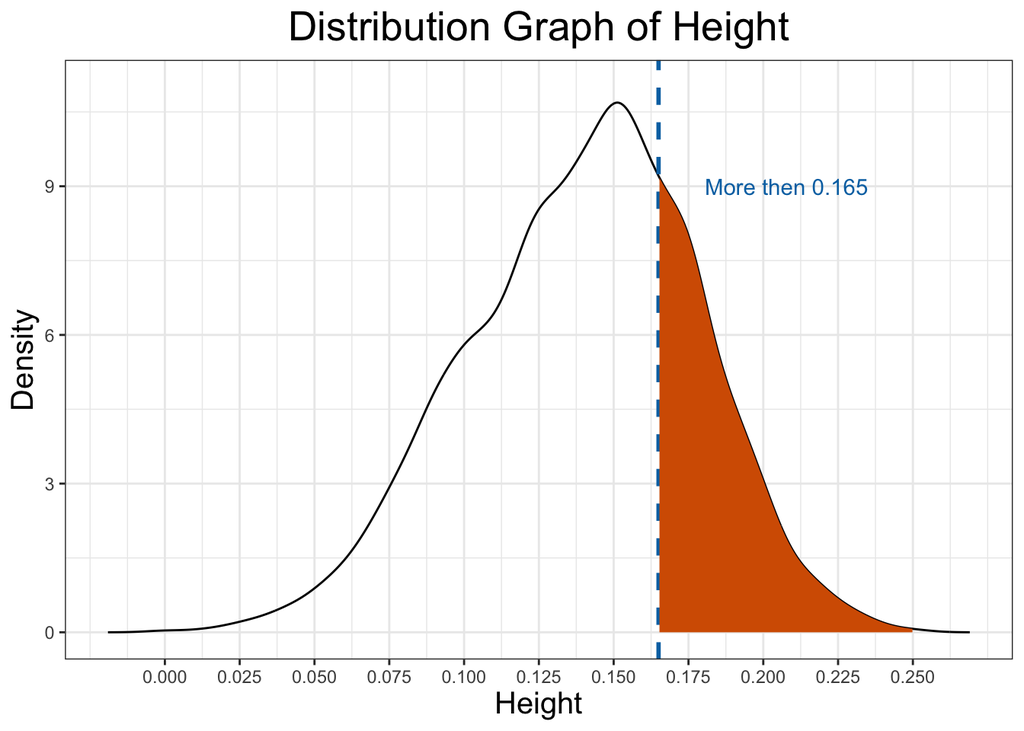

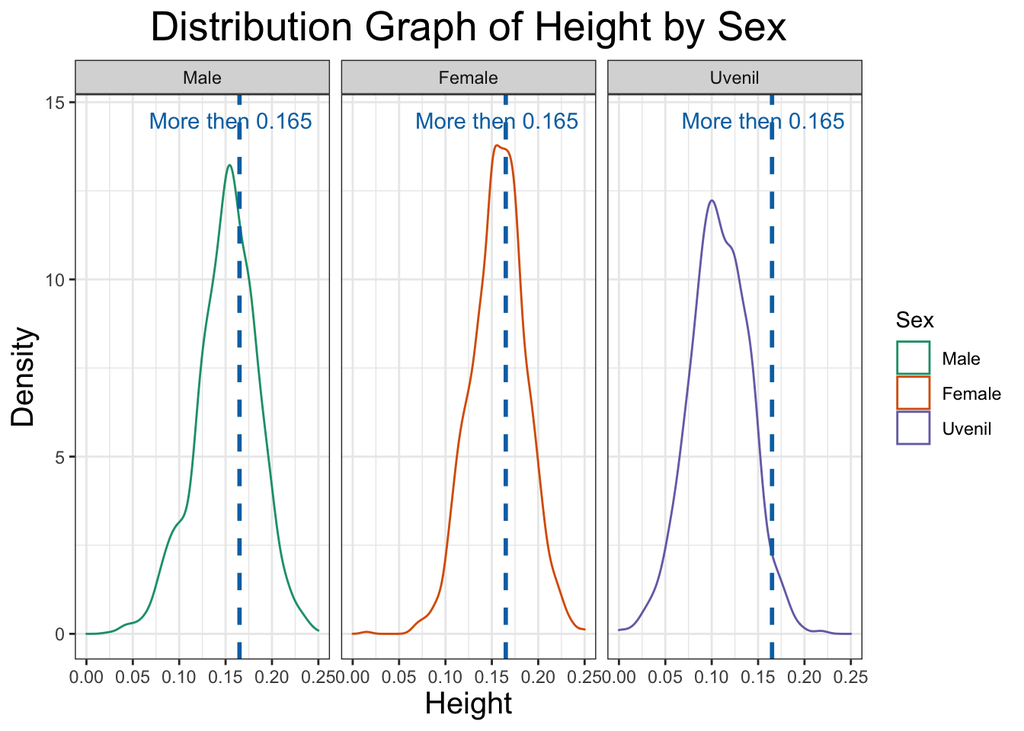

## 1.5 Значение переменной Length большее 92% всех набюлюдений

Рассчитаем значение длинны молюсков превышающее 92% всей выборки, применив функцию “quantile” и визуализируя полученное значение.

```
## Displaying Value Exceeding 92 Percent Variable Length Values =  0.67
```

[figure not shown]

## 1.6 Z - стандартизация переменной Length

Проведем Z-стандартизация для показателей длинны молюсков путем вычитания из каждого значения длинны среднего и деления разноти на стандартное отклонение. Визуализируем полученный результат.

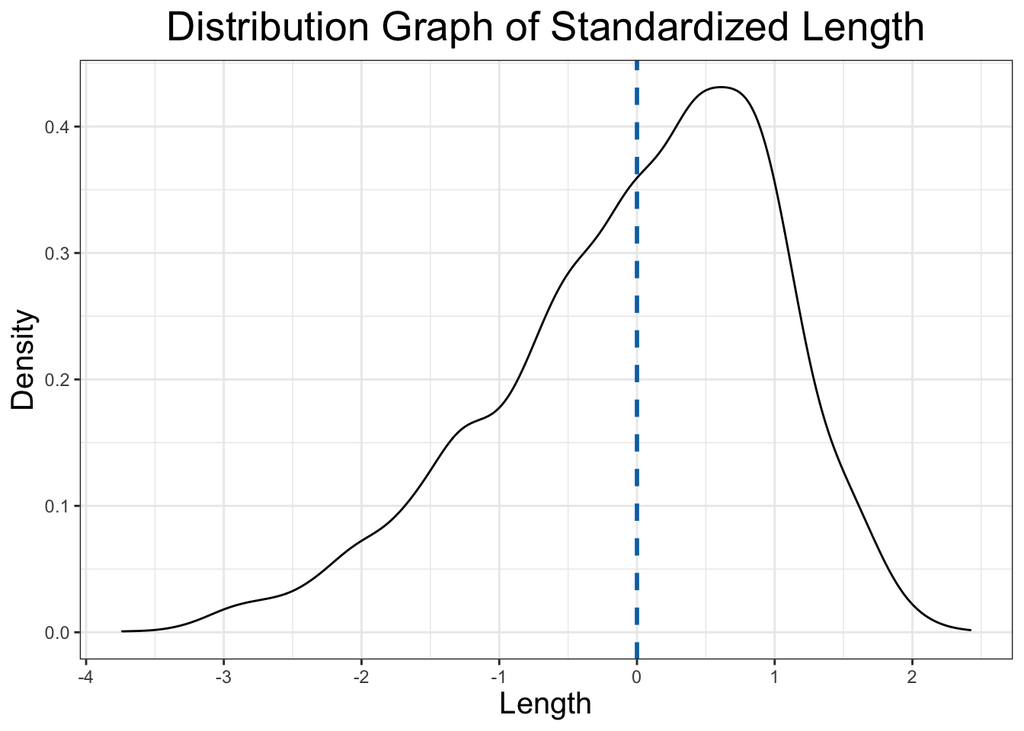

Как видно из графика среднее выборки по длинне раковины теперь равняется 0, а стандартное отклонение 1. Таким образом, Z - стандартизация прошла успешно.

## 1.7 Сравнение диаметра молюсков имеющих 5 и 15 колец

Произведем сравнение диаметра молюсков, имеющих 5 и 15 колец. На первом этапе данного анализа визуализируем распределение показателя диаметра в зависимости от числа колец в виде “box plot” диаграммы. Для наглядности также разделим молюсков на возростные группы:

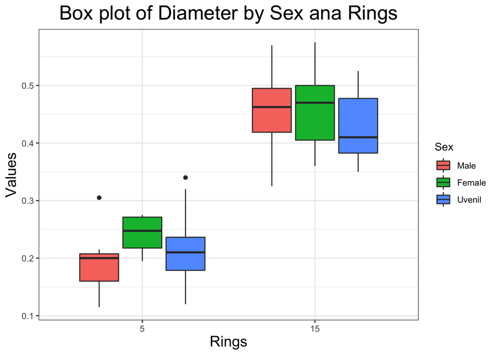

Как видно из графика в группе молюсков, имеющих на раковине 5 колец, наблюдается 2 явных выброса, котрые можно заменить на медианы для повышения точности анализа. После данной процедуры вновь визуализируем данные и проверим их на нормальность.

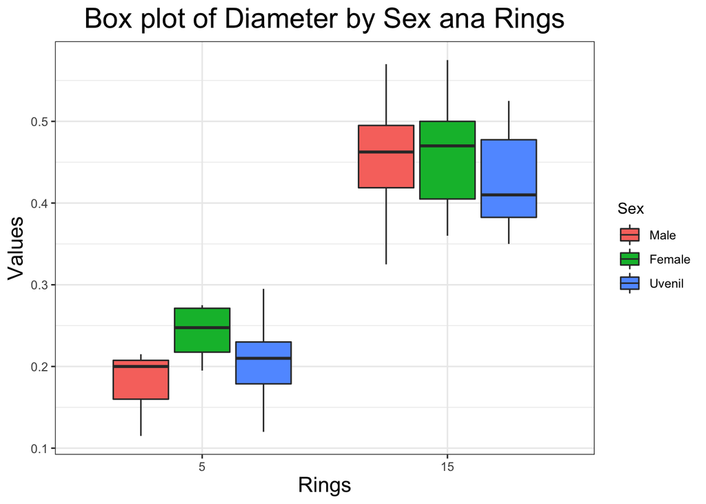

```
##
##  Shapiro-Wilk normality test
##
## data:  .
## W = 0.98162, p-value = 0.1161
```

```
##
##  Shapiro-Wilk normality test
##
## data:  .
## W = 0.98227, p-value = 0.1836
```

```
##
##  F test to compare two variances
##
## data:  Diameter by Rings
## F = 0.46959, num df = 114, denom df = 102, p-value = 9.712e-05
## alternative hypothesis: true ratio of variances is not equal to 1
## 95 percent confidence interval:
##  0.3205495 0.6851367
## sample estimates:
## ratio of variances
##          0.4695878
```

Проверим на нормальность группу молюсков с числом колец равным 5:

```
##
##  Shapiro-Wilk normality test
##
## data:  .
## W = 0.98162, p-value = 0.1161
```

p > 0.05 свидетельствует о невозможности отклонить гипотезу о нормальном распределении.

Проверим на нормальность группу молюсков с числом колец равным 15:

```
##
##  Shapiro-Wilk normality test
##
## data:  .
## W = 0.98227, p-value = 0.1836
```

p > 0.05 свидетельствует о но невозможности отклонить гипотезу о нормальном распределении.

Проверим равенство дисперсий рассматриваемых групп.

```
##
##  F test to compare two variances
##
## data:  Diameter by Rings
## F = 0.46959, num df = 114, denom df = 102, p-value = 9.712e-05
## alternative hypothesis: true ratio of variances is not equal to 1
## 95 percent confidence interval:
##  0.3205495 0.6851367
## sample estimates:
## ratio of variances
##          0.4695878
```

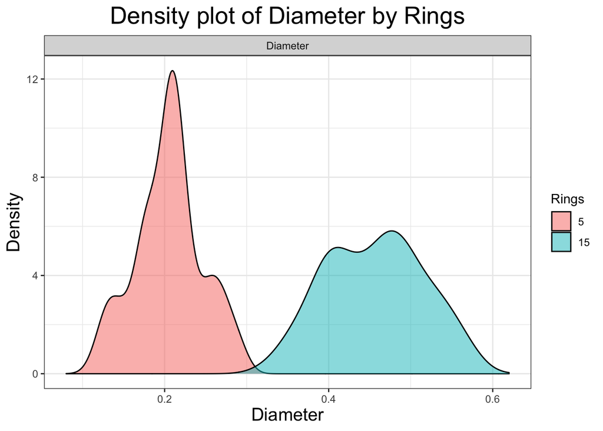

```
##
##  Two Sample t-test
##
## data:  Rings 5 group and Rings 15 group
## t = -36.941, df = 216, p-value < 2.2e-16
## alternative hypothesis: true difference in means is not equal to 0
## 95 percent confidence interval:
##  -0.2643935 -0.2376090
## sample estimates:
## mean of x mean of y
## 0.2052609 0.4562621
```

Таким образом, из значения t-теста и визуализации данных можно достоверно утверждать о том, что показатель диаметра отлечается у молюсков с 5 и 15 кольцами. В результате этого можно предположить, что у данного вида молюсков диаметр раковины увеличевается с увеличением числа колец, что подтверждается диаграммой корелляции. Однако, данная взаимосвязь является не линейной.

## 1.8 Кореляция диаметра раковины с весом молюска

Так как при начальной оценки данных было установленно, что диаметр раковины молюска связан с его весом нелинейно применим ранговый коофициент корелляции Спирмана.

```
##
##  Spearman's rank correlation rho
##
## data:  Diameter and Whole_weight
## S = 346993734, p-value < 2.2e-16
## alternative hypothesis: true rho is not equal to 0
## sample estimates:
##       rho
## 0.9712879
```

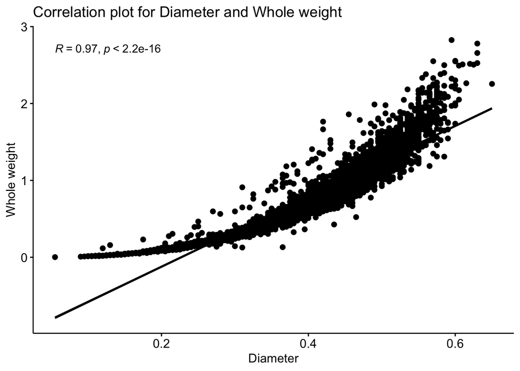

Таким образом, диаметр раковины имеет сильную взаимосвязь с весом молюска.